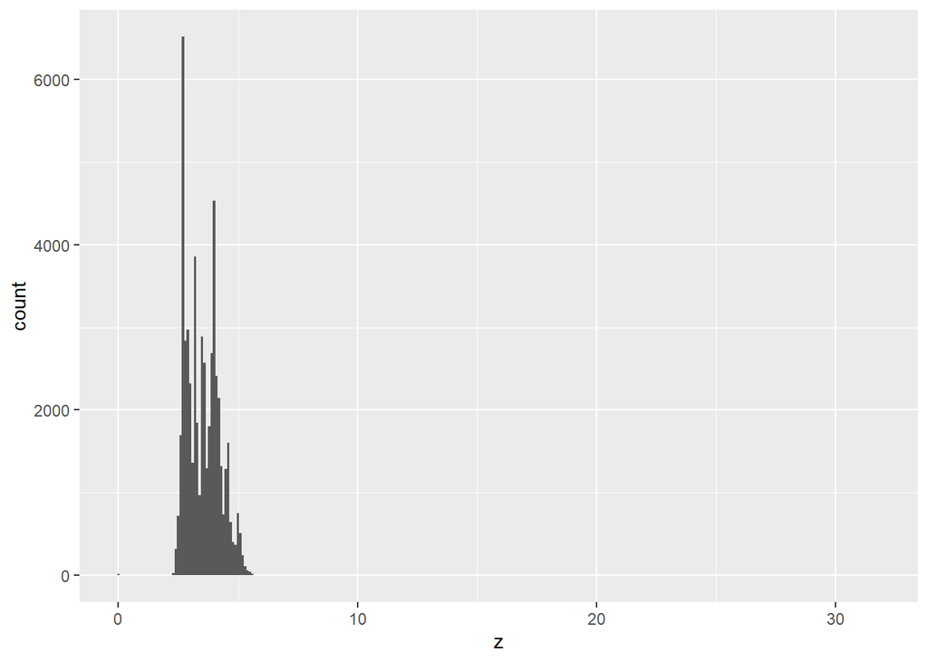

```r
#y는 MAX=58.9로, 오른쪽으로 긴 꼬리를 가지는 분포이다.

#z의 분포
ggplot(diamonds)+geom_histogram(aes(z),binwidth=0.1)
```

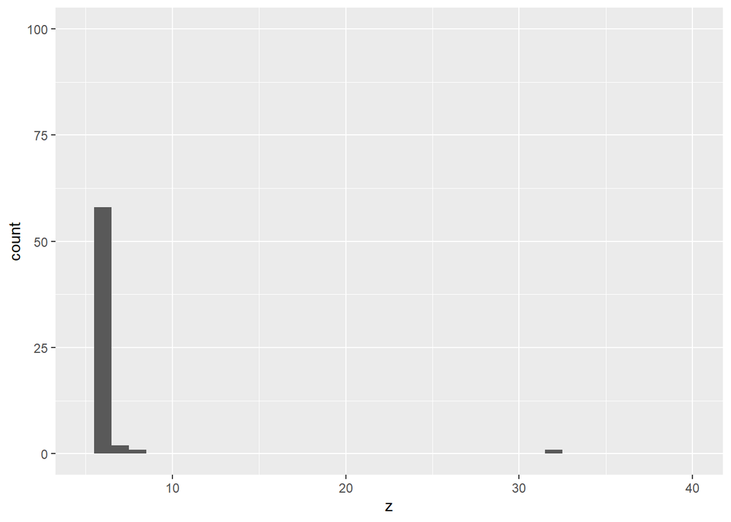

```r
ggplot(diamonds)+geom_histogram(aes(z),binwidth=1)+xlim(5,40)+ylim(0,100)
```

```r
#변수 z또한 MAX=31.800로, 오른쪽으로 긴 꼬리를 가지는 분포이다.


library(GGally)
```

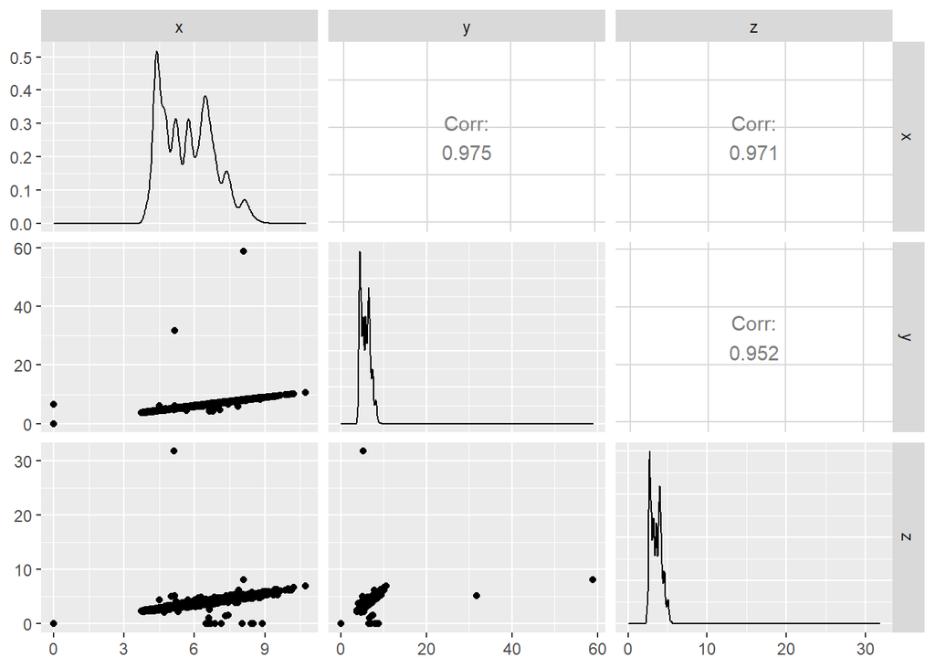

```r
ggpairs(diamonds[,c("x","y","z")])
```

변수들간 상관계수가 0.95이상으로 모두 높은 상관을 가지고 있는 것을 확인할 수 있다.

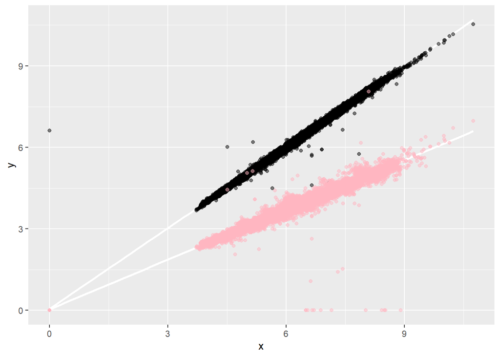

```r
#이상값 제거
diamonds2 <- diamonds %>%
 mutate(y = ifelse(y > 20, NA, y),
        z = ifelse(z > 20, NA, z))
ggplot(diamonds2) +geom_smooth(aes(x,y),method="lm",se=F,color="white")+
  geom_point(aes(x,y),alpha=0.5) +
  geom_smooth(aes(x,z),method="lm",se=F,color="white")+
  geom_point(aes(x,z), color = "lightpink",alpha=0.5)
```

주로 X와 y는 비슷한 추이를 보이나 Y의 최댓값이 더 크고, Z는 x보다 작은 값을 보인다. 따라서 Z는 가장 작은 값인 depth라는 것을 알 수 있고, x보다 더 큰값이 많이 분포한 y가 length라고 생각했지만, 데이터 설명에는 x가 length라고 명시되어 있다.

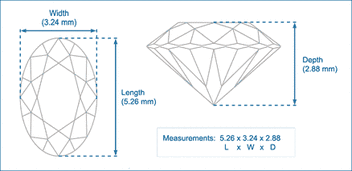

```r
#참고자료
library(knitr)
include_graphics("C:/temp/2021/stat_seminar/dia.gif")
```

### 2번

Explore the distribution of price. Do you discover anything unusual or surprising? (Hint: Carefully think about the binwidth and make sure you try a wide range of values.)

```r
summary(diamonds$price)
```

```
##    Min. 1st Qu.  Median    Mean 3rd Qu.    Max.
##     326     950    2401    3933    5324   18823
```

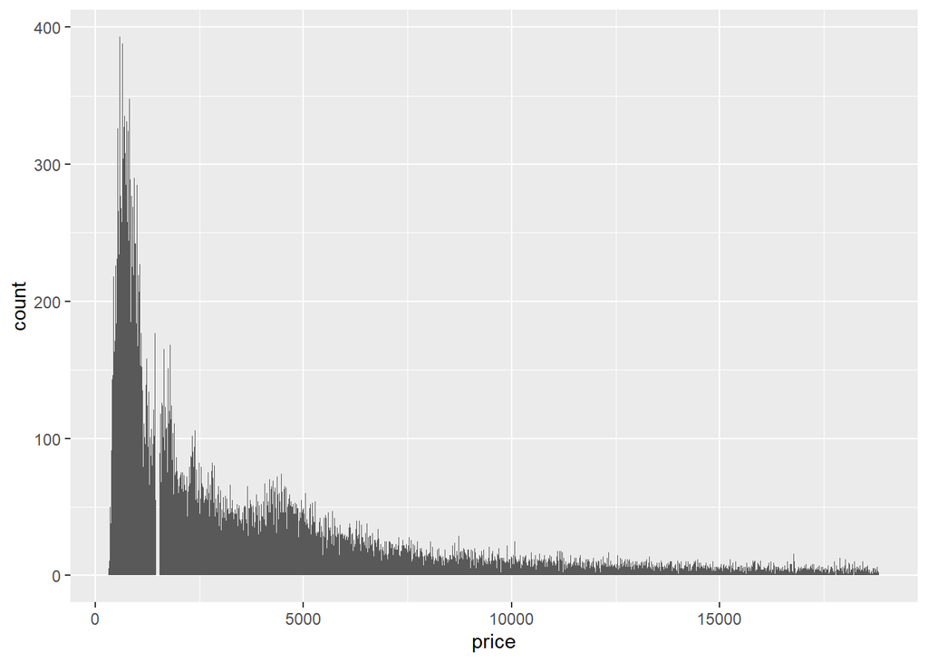

```r
ggplot(diamonds)+geom_histogram(aes(price),binwidth=10)
```

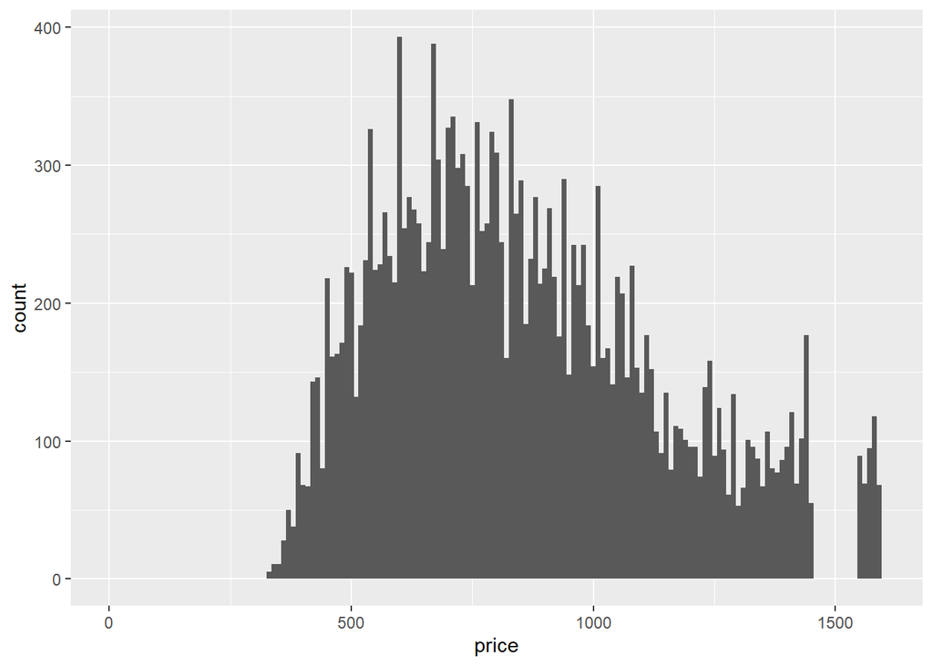

```r
ggplot(diamonds)+geom_histogram(aes(price),binwidth=10)+xlim(0,1600)
```

```r
diamonds%>%filter(price>1500)%>% arrange(price) %>% head()
```

```
## # A tibble: 6 x 10
##   carat cut     color clarity depth table price     x     y     z
##   <dbl> <ord>   <ord> <ord>   <dbl> <dbl> <int> <dbl> <dbl> <dbl>
## 1  0.51 Premium G     VS2      61.2    60  1546  5.17  5.12  3.15
## 2  0.51 Ideal   G     VS2      62.9    54  1546  5.12  5.08  3.21
## 3  0.51 Premium G     VS2      62.4    57  1546  5.11  5.09  3.18
## 4  0.51 Premium G     VS2      62.7    58  1546  5.12  5.09  3.2
## 5  0.51 Premium G     VS2      62.2    57  1546  5.15  5.1   3.19
## 6  0.51 Ideal   G     VS2      62.7    57  1546  5.12  5.05  3.19
```

```r
diamonds%>%filter(price<1500)%>% arrange(price) %>% tail()
```

```
## # A tibble: 6 x 10
##   carat cut       color clarity depth table price     x     y     z
##   <dbl> <ord>     <ord> <ord>   <dbl> <dbl> <int> <dbl> <dbl> <dbl>
## 1  0.54 Ideal     H     VS2      61.6    55  1453  5.23  5.25  3.23
## 2  0.54 Ideal     H     VS2      61.5    55  1453  5.25  5.28  3.24
## 3  0.54 Ideal     I     VS1      63.1    55  1453  5.18  5.22  3.27
## 4  0.5  Very Good D     SI1      61.6    56  1454  5.09  5.11  3.14
## 5  0.52 Ideal     I     VVS1     60.1    56  1454  5.24  5.27  3.16
## 6  0.54 Ideal     H     VS1      61.2    55  1454  5.25  5.31  3.23
```

### 3번

How many diamonds are 0.99 carat? How many are 1 carat? What do you think is the cause of the difference?

```r
diamonds%>%filter(carat %in% c(0.99,1))%>%group_by(carat)%>%summarise(n=n())
```

```
## # A tibble: 2 x 2
##   carat     n
## * <dbl> <int>
## 1  0.99    23
## 2  1     1558
```

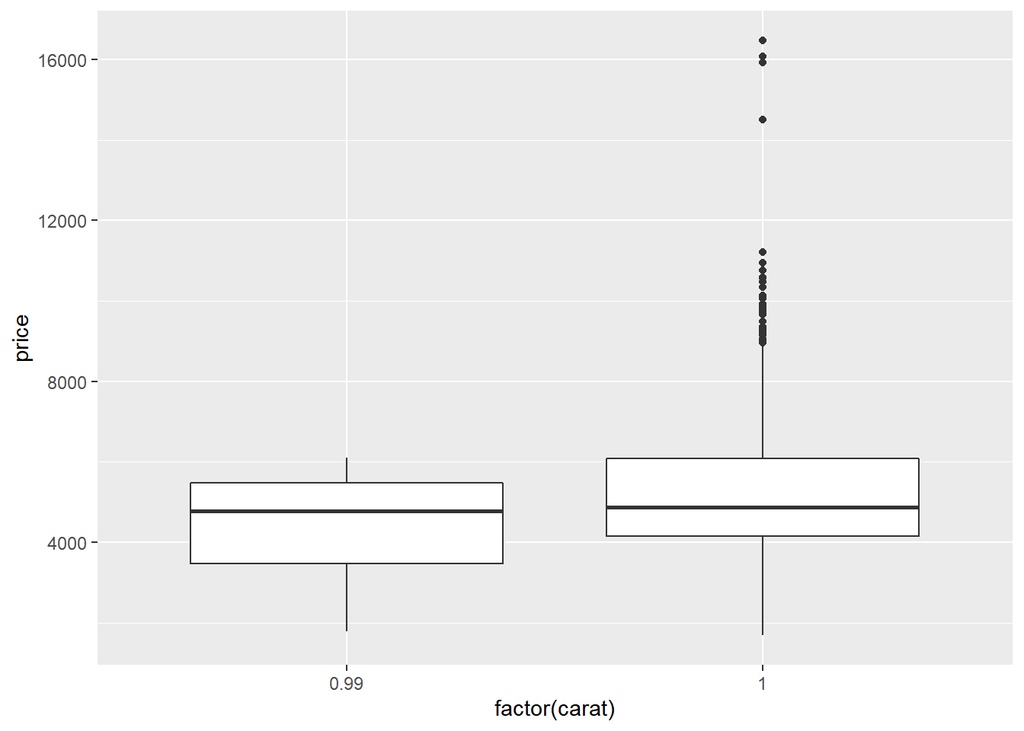

```r
#0.99 : 23개
#1 : 1558개

#두 경우의 가격 분포 확인
diamonds%>%filter(carat %in% c(0.99,1))%>%ggplot()+
  geom_boxplot(aes(factor(carat),price))
```

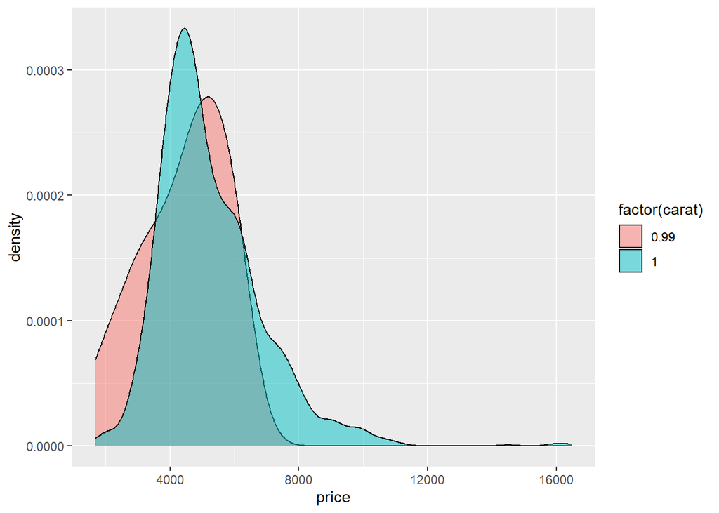

```r
diamonds%>%filter(carat %in% c(0.99,1))%>%
  ggplot()+
  geom_density(aes(price,group=factor(carat),fill=factor(carat)),alpha=0.5)
```

다이아몬드 캐럿은 오직 소수점 셋째자리가 9일 경우에 반올림하므로, 1과 0.99 carat의 다이아 가격의 차이가 크다고 한다. 따라서 0.99캐럿보다 1캐럿의 다이아 가격이 더 가치가 있으므로 1캐럿의 다이아가 더 많다고 추측할 수 있다. (참고 : https://lsk.pe.kr/3347)